# EpiInvert

Jean-David Morel, Jean-Michel Morel and Luis Alvarez

2023-12-31

- Overview
- OWID dataset
- Package installation
- Germany incidence decomposition using EpiInvert
- Modifying the regularity parameters
- Controlling the number of days in the past used by EpiInvert
- Using non-parametric serial interval
- Modifying parametric serial interval

### **Overview**

**EpiInvert** is a seasonal-trend decomposition method for the daily incidence, $i_t$, based on the following renewal equation:

$(1) \ \ \ \ s_ti_t=\sum_k s_{t-k}i_{t-k}R_{t-k}\Phi_k$

where $s_t$ is the seasonal component, $R_t$ is the case reproduction number and $\Phi_k$ is the serial interval. We assume that the serial interval is known and $R_t$, $s_t$ are computed by inverting the above renewal equation using signal processing techniques. The mathematical foundation of **EpiInvert** has been published in [PNAS, 2021](https://www.pnas.org/doi/10.1073/pnas.2105112118) and [Biology, 2022](https://www.mdpi.com/2079-7737/11/4/540). Once $R_t$ and $s_t$ are computed, the trend component (or restored incidence) $T_t$ and the normalized error $\varepsilon_t$ are defined as

$(2) \ \ \ \ T_t=\sum_ks_{t-k}i_{t-k}R_{t-k}\Phi_k$

$(3) \ \ \ \ \varepsilon_t = \frac{s_ti_t-T_t}{(T_t)^a}$

where $a$ is computed by minimizing the quadratic error

$(4) \ \ \ \ E(a,b)=\sum_t \left( log(|s_ti_t-T_t|) - a\cdot log(T_t)-b\right)^2$

**EpiInvert** also corrects the bias introduced by the festive days (or any anomalous day) where the user expects that the incidence value es biased. To correct the bias introduced by the festive days **EpiInvert** automatically update the incidence value in each festive day and the next 2 days. Typically, in the festive (or anomalous day), one observes a sharp decrease in the number of registered incidence that is compensated by increased incidence numbers in the next few days. This bias is corrected by redistributing the number of cases in the festive day and the next 2 days.

In a nutshell, **EpiInvert** is based on estimating all the variables involved, that is $s_t$, $R_t$ and the values of $i_t$ in the festive days and the next 2 days in order to minimize the difference between the incidence and its expected value using the renewal equation.

To model the serial interval, **EpiInvert** allows a shifted log-normal parametric formulation. The shift can be negative, reflecting the fact that secondary cases may present symptoms earlier than the primary case. The user can also provide a non-parametric serial interval given by a numeric vector.

### **owid dataset**

We use, **owid**, a dataset containing COVID-19 epidemiological indicators for Canada, France, Germany, Italy, UK and the USA obtained from [Our World in data](https://github.com/owid/covid-19-data/tree/master/public/data) up to 2022-11-28. In the case a data value is not available for a given day we assign the value 0 to the indicator. **owid** is a `dataframe` containing the following variables :

- `iso_code` : iso code of the country
- `location` : country name
- `date` : date of the indicator value
- `new_cases` : new confirmed cases
- `new_cases_smoothed` : new confirmed cases smoothed (as provided by [Our World in data](https://github.com/owid/covid-19-data/tree/master/public/data))
- `new_cases_restored_EpiInvert` : new confirmed cases restored using `EpiInvert`
- `new_deaths` : new deaths attributed to COVID-19
- `new_deaths_smoothed` : new deaths smoothed (as provided by [Our World in data](https://github.com/owid/covid-19-data/tree/master/public/data))
- `new_deaths_restored_EpiInvert` : new deaths restored using `EpiInvert`
- `icu_patients` : number of COVID-19 patients in intensive care units (ICUs) on a given day
- `hosp_patients` : number of COVID-19 patients in hospital on a given day
- `weekly_icu_admissions` : number of COVID-19 patients newly admitted to intensive care units (ICUs) in a given week (reporting date and the preceding 6 days)
- `weekly_hosp_admissions` : number of COVID-19 patients newly admitted to hospitals in a given week (reporting date and the preceding 6 days)

Not all countries have recorded values for all indicators in this database. For example, France and Italy have data for all the indicators, but the rest of the countries do not. Therefore, before using the data from a country, it is convenient to analyze, by exploring the dataset, which indicators have values other than zero.

### **Package installation**

You can install **EpiInvert** from the CRAN repository or from the [GitHub](https://github.com/) repository with:

```r
 install.packages("devtools")
 devtools::install_github("lalvarezmat/EpiInvert")
```

The **EpiInvert** installation from the source file requires a C++ compilation. To avoid this compilation step you can use the pre-compiled versions available at the CRAN repository.

We attach some required packages

```r
library(EpiInvert)
library(ggplot2)
library(dplyr)
library(grid)
```

We load the **owid** dataset:

```r
data(owid)
summary(owid)
```

[output not shown]

We filter the **owid** dataset to keep the data up to 2022-05-05:

```r
owid <- filter(owid,date<=as.Date("2022-05-05"))
```

Loading some festive days for the same countries:

```r
data(festives)
head(festives)
```

[output not shown]

### **Germany incidence decomposition using EpiInvert**

We show the execution of **EpiInvert** using Germany data. The first parameter is a numerical vector with the daily incidence, the second parameter is the date of the last incidence value and the third parameter is a character vector with the dates of the festive (or anomalous) days (this parameter is not mandatory)

```r
sel <- filter(owid, iso_code=="DEU")
res <- EpiInvert(sel$new_cases,"2022-05-05",festives$DEU)
```

Plotting the results:

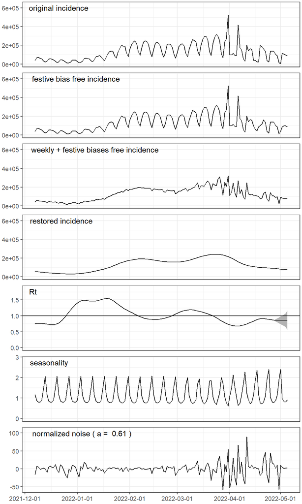

```r
EpiInvert_plot(res)
```

**EpiInvert** returns a list with the following elements:

- i_original : the original daily incidence curve. Notice that **EpiInvert** does not allow missing values. On days when a country does not report data, a zero must be registered as the value associated with the incidence of that day.
- i_festive : the festive days bias free incidence, $i_t$, with the correction of the bias introduced by the declared festive days.
- i_bias_free : the festive days and weekly biases free incidence given by $s_ti_t$ where $s_t$ is the seasonal component and $i_t$ the festive days bias free incidence
- i_restored : the restored incidence (or trend), $T_t$ (see equation (2)).
- Rt : time varying reproduction number $R_t$ (see equation (1)).
- Rt_CI95 : to estimate Rt on each day t, **EpiInvert** uses the past days (t’<=t) and the future days (t’>t) when available. Therefore, the **EpiInvert** estimate of Rt varies when more days are available. Rt_CI95 represents the radius of an empiric 95% confidence interval of the expected variation of Rt as a function of the number of days after t available (see the plot of Rt above).
- seasonality : the seasonal component $s_t$ (see equation (1).
- dates : the date associated with each incidence value.
- festive : a Boolean vector to indicate the days considered as festive.
- epsilon : the normalized error given by equation (3).
- power_a : the power a in equation (3). Note that this value strongly depends on the size of the incidence curve used by the **EpiInvert** estimation. As we shall see later, this size is an **EpiInvert** parameter. The estimated value of a only has sense in the case of a large incidence sequence.
- si_distr : numeric vector with the serial interval distribution used, it can be computed from the shifted parametric log-normal or it can be uploaded by the user
- shift_si_distr : shift of the serial interval used.

### **Modifying the regularity parameters**

**EpiInvert** allows to control the regularity of the seasonal component $s_t$ and/or $R_t$ using regularity parameters, the default values of both parameters are $5$. Next we apply **EpiInvert** to Germany incidence modifying these parameters:

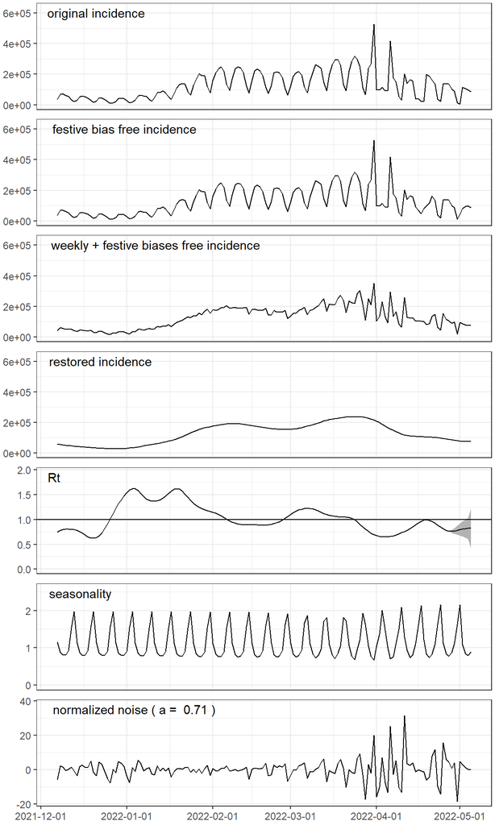

```r
res <- EpiInvert(sel$new_cases,"2022-05-05",festives$DEU,select_params(list(seasonality_regularization_weight = 10,Rt_regularization_weight=1)))
EpiInvert_plot(res)
```

With respect to the previous experiment we observe a larger variability of $R_t$ and a lower variation of $s_t-s_{t-7}$.

### **Controlling the number of days in the past used by EpiInvert**

**EpiInvert** execution for France using 365 days in the past. If you are not constrained by the computational cost of the algorithm, you can choose a large value of this parameter (for instance 9999), to ensure that **EpiInvert** will use the whole available sequence in the estimation.

```r
sel <- filter(owid, iso_code=="FRA")
res <- EpiInvert(sel$new_cases,"2022-05-05",festives$FRA,
                 select_params(list(max_time_interval = 365)))
```

Plot of the incidence between “2021-12-15” and “2022-01-15”. Observe that the festive days bias correction only modifies the original incidence in the festive days and the following 2 days.

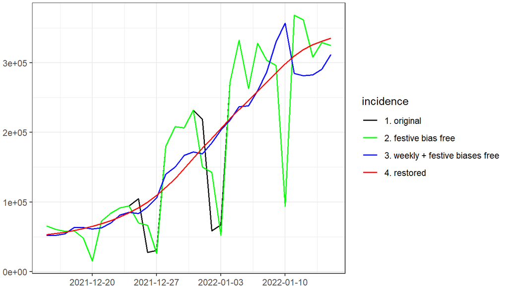

```r
 EpiInvert_plot(res,"incid","2021-12-15","2022-01-15")
```

### **Using non-parametric serial interval**

**EpiInvert** execution for UK using a non-parametric serial interval shifted -2 days

load data of a serial interval

```r
data(si_distr_data)
head(si_distr_data)
```

```
## [1] 3.285609e-06 3.401902e-04 3.904441e-03 1.543537e-02 3.466818e-02
## [6] 5.608451e-02
```

```r
sel <- filter(owid, iso_code=="GBR")
res <- EpiInvert(sel$new_cases,"2022-05-05",festives$UK,
       select_params(list(si_distr = si_distr_data,
       shift_si_distr=-2)))
```

Plot of the serial interval used (including the shift)

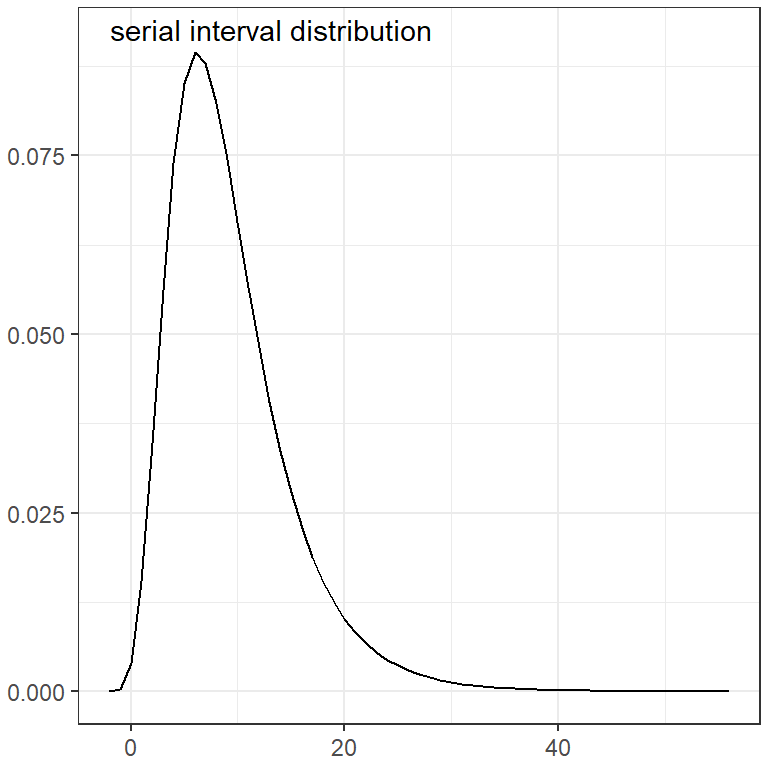

```r
 EpiInvert_plot(res,"SI")
```

### **Modifying parametric serial interval**

**EpiInvert** execution for the USA changing the default values of the parametric serial interval (using a shifted log-normal)

```r
sel <- filter(owid, iso_code=="USA")
res <- EpiInvert(sel$new_cases,"2022-05-05",festives$USA,
       select_params(list(mean_si = 11,sd_si=6,shift_si=-1)))
```

Plot of the reproduction number Rt including an empiric 95% confidence interval of the variation of **EpiInvert** Rt estimation as a function of the number of future days available.

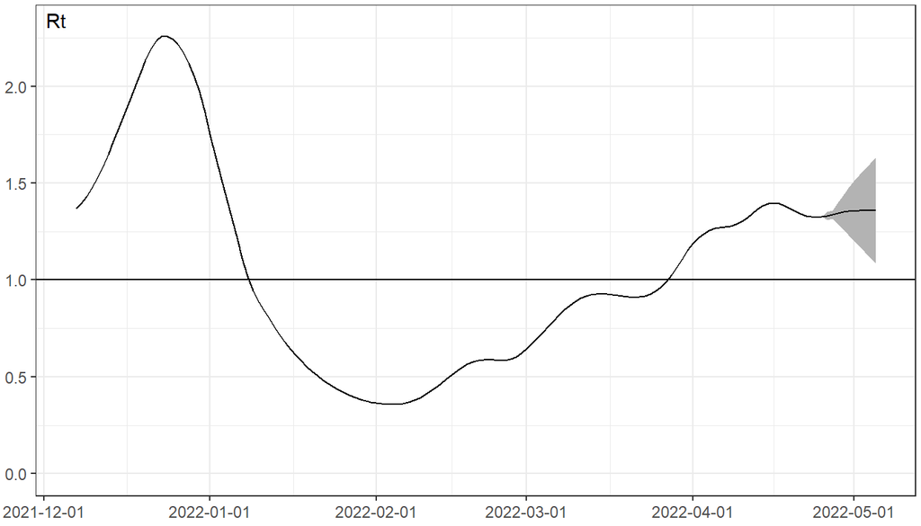

```r
 EpiInvert_plot(res,"R")
```